# Data Science Specialism

### Module 6 - Statistical Inference (June 2015)

## Investigating a sample population of 40 random exponential values and their relationship to the natural exponential density function using the Central Limit Theorem and Law of Large Numbers.

### Author: Fiona Young

### Submission date: 11 June 2015

### SUMMARY

The Central Limit Theorem states that the sampling distribution of any statistic will be normal or nearly normal if the sample size is large enough. The theoretical (exponential) density function and sample distribution means were almost identical at 5.075 and 5.042 respectively. The theoretical (exponential) density function and sample distribution variances were 24.734 and 0.058 respectively. To accurately represent the EDF it should have all its values centred around the mean value with a small variance and it does with the values for the theoretical (exponential) density function at 0.12 and sample means distribution 0.8 to 1.0. However a better reflection of sample variance would be to remove the first 200 mean values that fluctuate widely about the mean.

### INTRODUCTION

The Central Limit Theorem (CLT) definition on StatTrek (2015) states “that the sampling distribution of any statistic will be NORMAL or NEARLY NORMAL if the sample size is large enough”.

How do we know that the sample is large enough? We draw on the idea of the Law of Large Numbers (LLN). As we take a LLN (running mean) of the samples eventually the probability will be equivalent to the mean (mu) of a population density function. It is at this point of equivalence onwards that we can use the number of samples that accurately reflects the population density function.

According to some statistians a sample size of 30 to 40 values is large enough to be representative of a population density function (StatTrek 2015). Is this the case? Our sample size for this analysis has been set at 40 randomly generated exponential values.

We will attempt to answer three questions as they relate to an exponential density function and they are:

1. How does the theoretical mean and sample mean compare?
2. How does the theoretical variance and sample variance compare?
3. How does the theoretical density function and sample distribution curve differ?

#### What is an exponential density function?

Before proceeding to answer our three questions we ought to determine what is a exponential density function?

The equation for an exponential curve is given as:

```
y = e^x
```

where -

y = y axis of a graph x = x axis of a graph e is known as Euler’’s number (Wikipedia 2015a) as described by Leonhard Euler (Wikipedia 2015b).

e is an irrational number and the base of Natural Logarithms which were invented by John Napier (Wikipedia 2015c).

e is calculated:

```
e = 1/n!
```

The value of e is known to 1.250 billion digits of accuracy (Gourdon 1999). Here are the first 20 digits to get you started.

```
e = 2.7182818284590452353...
```

### METHODOLOGY / DATA PROCESSING

Loading R packages required for this analysis.

```r
##1 - loading R packages
library(MASS)
library(stringr)
library(knitr)
library(rmarkdown)

    ##NOTE - for knitr/rmarkdown to work in RCONSOLE you are required to download the PANDOC package available online at: http://pandoc.org/installing.html
```

For this analysis I will generate four graphs:

Two histograms demonstrating a normal population density function (figure 1) and an exponential density function (figure 2) both using 1000 random variables.

A line graph (figure 3) demonstrating the Law of Large Numbers (LLN) and a histogram of the means of generated by 1000 simulations of 40 random exponential variables (figure 4).

In order to compare the distribution curves in figures 2 and 4 requires the generation of mean and variance values.

### RESULTS

The calculated mean and variance for an exponential density function and a sample population of 40 exponentials.

```r
title <- "Table 1 Comparison of mean and variance"
EDF <- cbind("Exponential Density Function", round(mean(exponentials), digits = 3), round(var(exponentials), digits = 3))
SDC <- cbind("Sample distribution", round(mean(samplemeans), digits = 3), round(var(samplemeans), digits = 3))
comparison <- rbind(EDF, SDC)
colnames(comparison) <- c("analysis?", "Mean", "Variance")

row.names(comparison) <- NULL
print(title)
```

```
## [1] "Table 1 Comparison of mean and variance"
```

```r
comparison
```

```
##      analysis?                      Mean    Variance
## [1,] "Exponential Density Function" "5.075" "24.734"
## [2,] "Sample distribution"          "5.042" "0.058"
```

The four graphs:

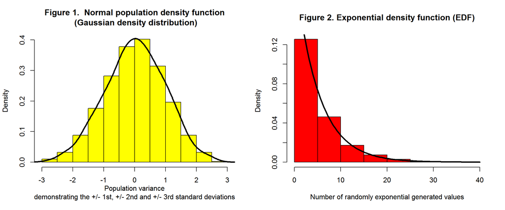

```r
par(mfrow = c(1,2))

    ##1 - plotting the PDF graph
    hist(population, col = "yellow", main = "Figure 1.  Normal population density function\n (Gaussian density distribution)", xlab = "Population variance\ndemonstrating the +/- 1st, +/- 2nd and +/- 3rd standard deviations", probability = TRUE)

    ##1.2 - plotting the density curve
    lines(density(population), col = "black", lwd = 3)

        ##2 - graphic EDF
        hist(exponentials, prob = TRUE, col = "red", xlab = "Number of randomly exponential generated values", main = "Figure 2. Exponential density function (EDF)")

        ##2.1 - plotting the natural exponential line
        x.est <- fitdistr(exponentials, "exponential")$estimate
        curve(dexp(x, rate = x.est), add = TRUE, col = "black", lwd = 3)
```

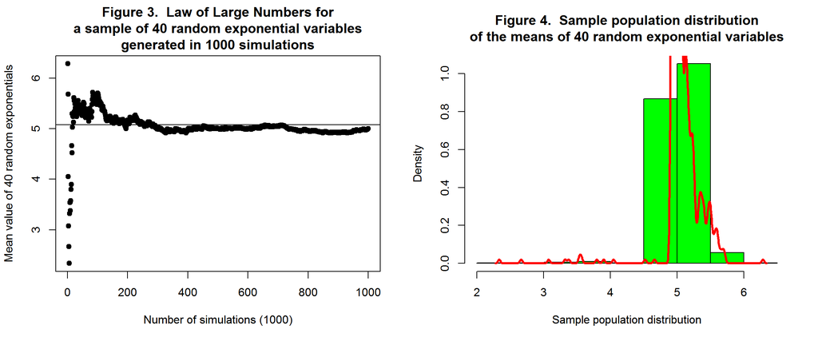

```r
par(mfrow = c(1,2))

            ##3 - plotting the graph of Law of Large Numbers
            plot(samplemeans, xlab = "Number of simulations (1000)", ylab = "Mean value of 40 random exponentials", pch = 19, main = "Figure 3.  Law of Large Numbers for\na sample of 40 random exponential variables\ngenerated in 1000 simulations")

            ##3.1 - plotting a line to represent the mean value of the exponential density function
            abline(h = mean(exponentials))

                ##4 - plotting a histogram of mean value of 40 exponentials
                hist(samplemeans, xlab = "Sample population distribution", col = "green", main = "Figure 4.  Sample population distribution\nof the means of 40 random exponential variables", prob = TRUE)

                ##4.1 - plotting the sample population curve
                lines(density(samplemeans), col = "red", lwd = 3)
```

### CONCLUSION

This analysis addresses three questions relating to an exponential density function and a sample population of 40 exponentials values.

Question 1 - How does the theoretical mean and sample mean compare?

Table 1 demonstrates that the mean value for the theoretical or exponential density function and a sample population of 40 exponentials is 5.075 and 5.042 respectively. The mean values are both five which is what we would expect as our sample population is meant to accurately represent a normal population.

Question 2 - How does the theoretical variance and sample variance compare?

Referring back to table 1 the variances of the theoretical or exponential density function and sample population of 40 exponentials is 24.73 and 0.058 respectively. The variance is remarkably different.

Question 3 - How does the theoretical density function and sample distribution curves differ?

Going back to the Central Limit Theorem where “the sampling distribution of any statistic will be NORMAL or NEARLY NORMAL if the sample size is large enough”. According to some statistians 30 to 40 samples is enough to satisfy the Central Limit Theorem is this the case?

Comparing the theoretical (exponential) density function (figure 2) and sample means distribution (figure 4) shows a peak density of 0.12 and 0.8 to 1.0 respectively. We expected that figure 4 if it is to accurately represent the EDF it should have all its values centred around the mean value with a small variance and it does.

However if we look at figure 3 you can see using the Law of Large Numbers that 30 - 40 samples does not reflect the mean value of five until approximately 200 means have been simulations. Therefore a sample of 40 exponentials is not enough. To get a sample distribution to accurately reflect a Exponential density function we have to remove the first 200 mean values that fluctuate widely about the mean.

### REFERENCES

Gourdon X (1999) Plouffe’s Inverter: e to 1.250 billion digits, accessed at 17:35 on 9 June 2015 from http://www.plouffe.fr/simon/constants/expof1.txt

StatTrek.com (2015) Central Theorem Limit accessed at 11:30 on 9 June 2015 from http://stattrek.com/statistics/dictionary.aspx?definition=central_limit_theorem

Wikipedia (2015a) Euler’s number accessed at 17:20 on 9 June 2015 from http://en.wikipedia.org/wiki/E_%28mathematical_constant%29

Wikipedia (2015b) Leonhard Euler accessed at 17:20 on 9 June 2015 from http://en.wikipedia.org/wiki/Leonhard_Euler

Wikipedia (2015c) John Napier accessed at 17:20 on 9 June 2015 from http://en.wikipedia.org/wiki/John_Napier

### APPENDICES

40 sample exponential variables

```r
sample
```

```
##  [1] 15.44421174  0.68732681  0.60731556  1.02365172  7.82562477
##  [6]  4.57371506  7.87584087  5.08470324  0.77564653  6.28346564
## [11]  3.94420770 16.89014699  2.55998245 14.56226207  7.11715534
## [16]  2.68830275  5.34085407  0.15491966  2.88076285 14.10709658
## [21]  1.24020705  9.24447407  3.30286123  0.03428685  8.38628913
## [26]  2.11974987  0.80533696  7.53320797  9.03369072  4.14366365
## [31]  0.58561270  3.78671309  5.12475449  4.32507555  2.90772486
## [36]  0.28394962  1.53150097  4.91321994  0.54359962  5.02795790
```

The 1000 sample means generated from the 40 exponential variables

```r
samplemeans
```

[output not shown]

[output cut: 128 more lines]

##### generating an html document to convert into a pdf file

render(“project1.Rmd”, html_document())